# Übung 04: Kennwerte und deren Visualisierung — Lösung

Politik vermessen: Quantitative Methoden mit R | SoSe 2026 | Maura Kratz

Published

01.07.2026

# Setup

```r
library(dplyr)
library(skimr)
library(here)
```

# Aufgabe 1: Daten laden und vorbereiten

Lade den Datensatz `btw_2025_ergebnisse.RData` mit `here::here()`. Filtere anschließend die Wahlkreise und die Wahlbeteiligung heraus (Gruppe: `Wählende`). Speichere das Ergebnis in einem neuen Obejkt namens `wb`. Wie viele Zeilen hat der gefilterte Datensatz?

```r
load(here::here("output/btw_2025_ergebnisse.RData"))

wb <- btw_2025_ergebnisse %>%
  dplyr::filter(
    gebietsart == "Wahlkreis",
    gruppenname == "Wählende"
  )

nrow(wb)
```

```
[1] 299
```

```r
# stattdessen kannst du auch den Datensatz öffnen und die Zeilen zählen.
```

*Der gefilterte Datensatz enthält 299 Zeilen — eine pro Wahlkreis.*

# Aufgabe 2: Kennwerte berechnen

Berechne mit `dplyr::summarise()` folgende Kennwerte für die Wahlbeteiligung (Variable `prozent`): n, Minimum, Maximum, Spannweite, Mittelwert, Standardabweichung, Median, Mittlere Abweichung vom Median, Q25, Q75 und IQR. Nutze `dplyr::as_tibble`` für eine übersichtliche Ausgabe.

```r
wb %>%
  dplyr::summarise(
    n = dplyr::n(),
    min = min(prozent, na.rm = TRUE),
    max = max(prozent, na.rm = TRUE),
    range = max(prozent, na.rm = TRUE) - min(prozent, na.rm = TRUE),
    mittelwert = mean(prozent, na.rm = TRUE),
    sd = sd(prozent, na.rm = TRUE),
    median = median(prozent, na.rm = TRUE),
    mad = mad(prozent, na.rm = TRUE),
    q25 = quantile(prozent, probs = 0.25, na.rm = TRUE),
    q75 = quantile(prozent, probs = 0.75, na.rm = TRUE),
    iqr = IQR(prozent, na.rm = TRUE)
  ) %>%
  dplyr::as_tibble()
```

```
# A tibble: 1 × 11
      n   min   max range mittelwert    sd median   mad   q25   q75   iqr
  <int> <dbl> <dbl> <dbl>      <dbl> <dbl>  <dbl> <dbl> <dbl> <dbl> <dbl>
1   299  73.4  88.0  14.6       82.4  2.62   82.9  2.25  81.1  84.3  3.16
```

Was sagen dir die Kennwerte? Interpretiere Mittelwert vs. Median und die Streuung.

# Aufgabe 3: Visualisierung

Erstelle einen Boxplot der Wahlbeteiligung.

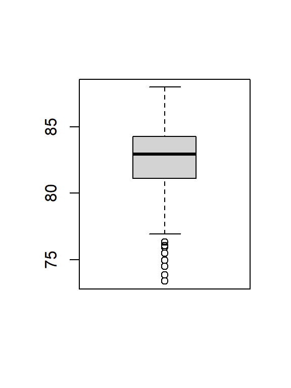

```r
boxplot(wb$prozent)
```

# Aufgabe 4: Extremfälle

In welchen drei Wahlkreisen war die Wahlbeteiligung am niedrigsten, in welchen am höchsten?

```r
wb %>%
  dplyr::select(gebietsnummer, gebietsname, prozent) %>%
  dplyr::arrange(prozent) %>%
  head(3)
```

```
  gebietsnummer             gebietsname  prozent
1           115             Duisburg II 73.39475
2            55 Bremen II – Bremerhaven 73.85110
3           122           Gelsenkirchen 74.49673
```

```r
wb %>%
  dplyr::select(gebietsnummer, gebietsname, prozent) %>%
  dplyr::arrange(prozent) %>%
  tail(3)
```

```
    gebietsnummer  gebietsname  prozent
297           220 München-Land 87.51043
298           128      Münster 87.51841
299            93      Köln II 87.98255
```

*Die Wahlkreise mit der niedrigsten Wahlbeteiligung liegen tendenziell in ehemaligen Industriestädten. Sowohl die Wahlkreise mit der höchsten, als auch jene mit der niedrigsten Wahlnbeteiligung liegen in städtischen Gebieten und in Westdeutschland.*

# Aufgabe 5: Bundesland-Mapping

Führe zunächst folgenden Code aus, um den Wahlkreisen ihre Bundeslandnamen zuzuordnen. Erkläre in eigenen Worten, was die beiden Codeblöocke hier machen.

```r
bula_mapping <- btw_2025_ergebnisse %>%
  dplyr::filter(gebietsart == "Land") %>%
  dplyr::select(bula_nr = gebietsnummer, bula_name = gebietsname) %>%
  dplyr::distinct()

wb <- wb %>%
  dplyr::left_join(bula_mapping, by = c("ueg_gebietsnummer" = "bula_nr")) %>%
  dplyr::rename(ueg_gebietsname = bula_name) %>%
  dplyr::relocate(ueg_gebietsname, .after = ueg_gebietsnummer)
```

*Zunächst wird eine Tabelle erstellt, in der jeder Bundeslandnummer der dazugehörige Bundeslandname zugeordnet wird. Die Angaben dazu werden aus den Variablen `gebietsnummer` und `gebietsname` des Datensatzes `btw_2025_ergebnisse` entnommen. `left_join` verbindet zwei Datensätze anhand einer gemeinsamen Variable. In diesem Fall wird, basierend auf der Übereinstimmung von `ueg_gebietsnummer` (in `wb`) und `bula_nr` (in `bula_mapping`), jeder übergeordneten Gebietnummer der dazugehörige Bundeslandsname zugewiesen.*

# Aufgabe 6: Kennwerte nach Bundesland

Gruppiere den Datensatz nach Bundesland und berechne die Kennwerte der Wahlbeteiligung pro Bundesland. Erstelle außerdem einen gruppierten Boxplot.

```r
wb %>%
  dplyr::group_by(ueg_gebietsname) %>%
  dplyr::summarise(
    n = dplyr::n(),
    min = min(prozent, na.rm = TRUE),
    max = max(prozent, na.rm = TRUE),
    range = max(prozent, na.rm = TRUE) - min(prozent, na.rm = TRUE),
    mittelwert = mean(prozent, na.rm = TRUE),
    sd = sd(prozent, na.rm = TRUE),
    median = median(prozent, na.rm = TRUE),
    mad = mad(prozent, na.rm = TRUE),
    q25 = quantile(prozent, probs = 0.25, na.rm = TRUE),
    q75 = quantile(prozent, probs = 0.75, na.rm = TRUE),
    iqr = IQR(prozent, na.rm = TRUE)
  ) %>%
  dplyr::as_tibble()
```

```
# A tibble: 16 × 12
   ueg_gebietsname       n   min   max range mittelwert    sd median   mad   q25
   <chr>             <int> <dbl> <dbl> <dbl>      <dbl> <dbl>  <dbl> <dbl> <dbl>
 1 Baden-Württemberg    38  78.4  86.2  7.78       83.4 1.69    83.4 1.61   82.3
 2 Bayern               47  78.3  87.5  9.20       84.2 2.00    84.3 2.08   83.0
 3 Berlin               12  75.5  84.7  9.18       80.1 3.38    80.2 3.88   77.4
 4 Brandenburg          10  78.5  85.7  7.20       81.2 2.53    79.8 1.64   79.5
 5 Bremen                2  73.9  81.2  7.35       77.5 5.19    77.5 5.45   75.7
 6 Hamburg               6  76.1  85.6  9.55       81.1 4.28    81.1 5.52   77.8
 7 Hessen               22  79.2  85.8  6.63       83.1 1.90    83.4 1.86   81.8
 8 Mecklenburg-Vorp…     6  77.9  81.0  3.06       79.5 1.35    79.5 1.76   78.4
 9 Niedersachsen        30  81.1  86.4  5.28       83.4 1.35    83.5 1.60   82.3
10 Nordrhein-Westfa…    64  73.4  88.0 14.6        82.0 2.84    82.3 2.11   80.4
11 Rheinland-Pfalz      15  79.2  85.5  6.30       82.9 1.52    83.3 1.46   82.1
12 Saarland              4  79.7  85.2  5.46       82.5 2.27    82.5 2.37   81.4
13 Sachsen              16  78.8  84.2  5.44       81.0 1.66    81.2 1.54   79.6
14 Sachsen-Anhalt        8  76.9  78.5  1.60       77.7 0.583   77.4 0.507  77.3
15 Schleswig-Holste…    11  80.2  85.1  4.90       83.4 1.41    83.2 0.836  82.8
16 Thüringen             8  78.9  83.0  4.16       80.7 1.39    80.3 1.55   79.9
# ℹ 2 more variables: q75 <dbl>, iqr <dbl>
```

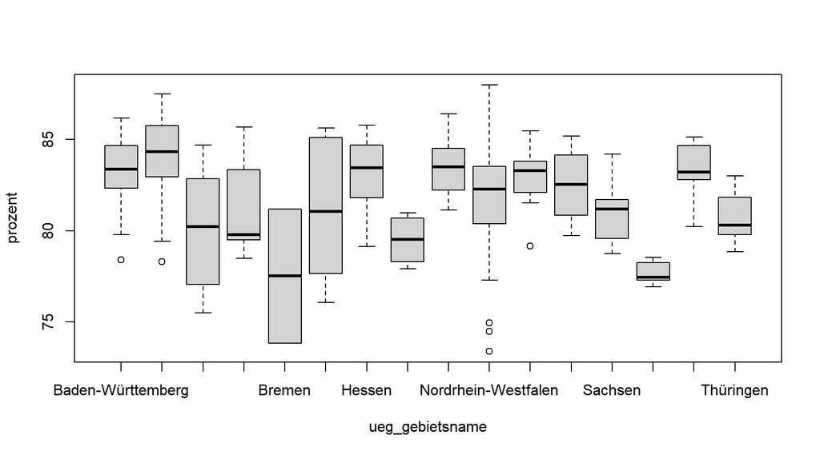

```r
boxplot(prozent ~ ueg_gebietsname,
        data = wb)
```

Beantworte anschließend folgende Fragen:

**a)** Schau dir Sachsen-Anhalt genauer an. Was fällt dir auf, wenn du Mittelwert, Median und die Streuung betrachtest? Was sagt das über die Wahlkreise dort aus?

**b)** Vergleiche Bayern und Nordrhein-Westfalen: Beide haben viele Wahlkreise — aber was unterscheidet sie in ihrem Schwerpunkt und ihrer Streuung? Was sagt das aus?

*Bayern (n = 47) und NRW (n = 64) haben beide viele Wahlkreise, unterscheiden sich aber deutlich in der Streuung: Bayern hat SD = 2.00 und IQR = 2.81, NRW dagegen SD = 2.84 und IQR = 3.11 — und vor allem eine Spannweite von 14.6 PP gegenüber 9.2 PP in Bayern. NRW ist also intern viel heterogener: zwischen städtischen Wahlkreisen (z.B. Ruhrgebiet) und ländlichen Wahlkreisen gibt es erhebliche Unterschiede in der Wahlbeteiligung.*